# Homework 4

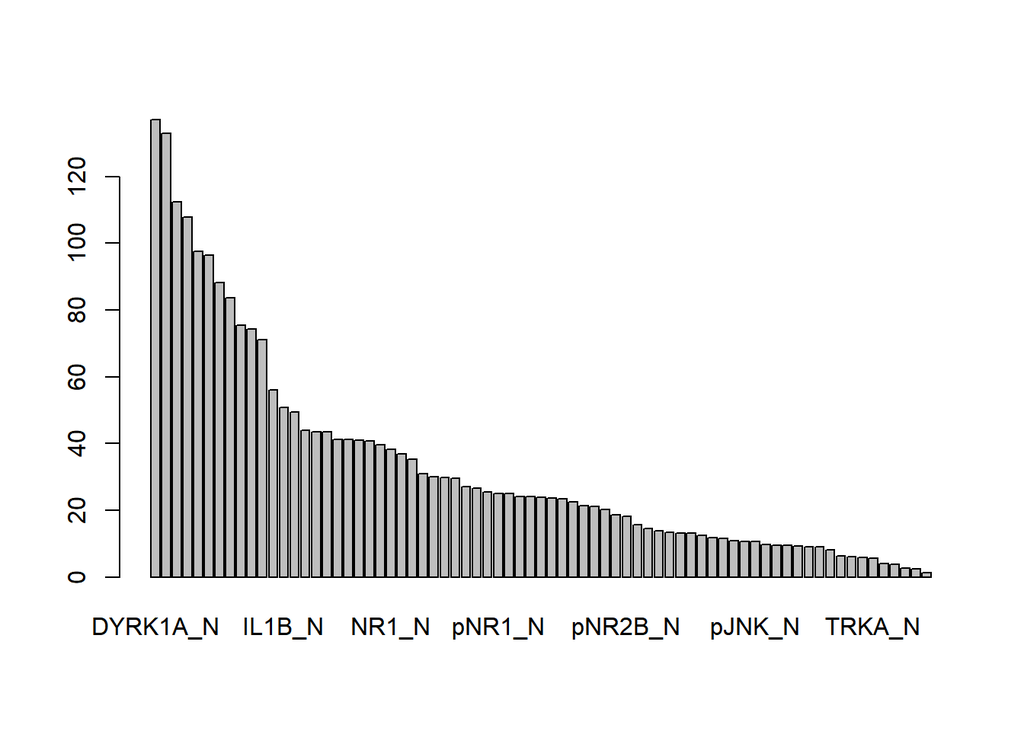

```r
barplot(fit.opt.rpart$variable.importance)
```

```r
rpart.preds=predict(fit.opt.rpart,test_nuclear,type="class")

conf.mat<-confusionMatrix(table(rpart.preds,test_nuclear$Y))
print(conf.mat)
```

```
## Confusion Matrix and Statistics
##
##
## rpart.preds c1 c2 c3 c4 c5 c6 c7 c8
##          c1 37  5  0  0  1  1  0  0
##          c2  5 28  0  0  4  0  0  0
##          c3  1  1 38  1  0  0  2  1
##          c4  0  0  1 41  0  0  2  5
##          c5  9  3  0  0 43  1  0  0
##          c6  0  2  0  0  5 29  0  0
##          c7  0  0  1  0  0  0 27  0
##          c8  0  0  0  2  0  0  3 25
##
## Overall Statistics
##
##                Accuracy : 0.8272
##                  95% CI : (0.7815, 0.8667)
##     No Information Rate : 0.1636
##     P-Value [Acc > NIR] : < 2.2e-16
##
##                   Kappa : 0.8014
##
##  Mcnemar's Test P-Value : NA
##
## Statistics by Class:
##
##                      Class: c1 Class: c2 Class: c3 Class: c4 Class: c5
## Sensitivity             0.7115   0.71795    0.9500    0.9318    0.8113
## Specificity             0.9743   0.96842    0.9789    0.9714    0.9520
## Pos Pred Value          0.8409   0.75676    0.8636    0.8367    0.7679
## Neg Pred Value          0.9464   0.96167    0.9929    0.9891    0.9627
## Prevalence              0.1605   0.12037    0.1235    0.1358    0.1636
## Detection Rate          0.1142   0.08642    0.1173    0.1265    0.1327
## Detection Prevalence    0.1358   0.11420    0.1358    0.1512    0.1728
## Balanced Accuracy       0.8429   0.84318    0.9644    0.9516    0.8817
##                      Class: c6 Class: c7 Class: c8
## Sensitivity            0.93548   0.79412   0.80645
## Specificity            0.97611   0.99655   0.98294
## Pos Pred Value         0.80556   0.96429   0.83333
## Neg Pred Value         0.99306   0.97635   0.97959
## Prevalence             0.09568   0.10494   0.09568
## Detection Rate         0.08951   0.08333   0.07716
## Detection Prevalence   0.11111   0.08642   0.09259
## Balanced Accuracy      0.95580   0.89533   0.89469
```

```r
rpart.perf<-conf.mat$overall["Accuracy"]
print(rpart.perf)
```

```
##  Accuracy
## 0.8271605
```

```r
sqrt(ncol(Traindat))# mtry is selected around this value
```

```
## [1] 8.774964
```

```r
Grid.Matrix= expand.grid(mtry=c(4,6,7,8,10,12))
control.param$allowParallel<-T
cl <- makeCluster(8)
registerDoSNOW(cl)
set.seed(123)
fit.rf <- caret::train(x = Traindat ,
                       y = TrainResponse,
                       method = "rf",
                       trControl = control.param,
                       tuneGrid = Grid.Matrix,
                       metric="Accuracy",
                       ntree=500,
                       nodesize=5)
stopCluster(cl)

print(fit.rf)
```

```
## Random Forest
##
## 756 samples
##  77 predictor
##   8 classes: 'c1', 'c2', 'c3', 'c4', 'c5', 'c6', 'c7', 'c8'
##
## No pre-processing
## Resampling: Cross-Validated (10 fold)
## Summary of sample sizes: 681, 679, 678, 681, 682, 681, ...
## Resampling results across tuning parameters:
##
##   mtry  logLoss    AUC        prAUC      Accuracy   Kappa      Mean_F1
##    4    0.4775058  0.9995537  0.8873199  0.9801187  0.9772267  0.9805404
##    6    0.4368029  0.9996750  0.8878513  0.9854867  0.9833787  0.9857767
##    7    0.4232630  0.9997487  0.8872256  0.9801533  0.9772696  0.9806587
##    8    0.4173762  0.9996841  0.8891139  0.9840314  0.9817161  0.9842335
##   10    0.3973771  0.9996504  0.8902620  0.9800827  0.9771884  0.9805124
##   12    0.3877229  0.9997644  0.8909584  0.9840148  0.9816891  0.9844223
##   Mean_Sensitivity  Mean_Specificity  Mean_Pos_Pred_Value  Mean_Neg_Pred_Value
##   0.9807481         0.9971464         0.9827234            0.9971967
##   0.9860859         0.9979244         0.9869406            0.9979436
##   0.9808870         0.9971522         0.9828093            0.9971995
##   0.9849495         0.9977262         0.9852462            0.9977348
##   0.9810606         0.9971493         0.9825340            0.9971881
##   0.9848106         0.9977091         0.9857284            0.9977344
##   Mean_Precision  Mean_Recall  Mean_Detection_Rate  Mean_Balanced_Accuracy
##   0.9827234       0.9807481    0.1225148            0.9889472
##   0.9869406       0.9860859    0.1231858            0.9920051
##   0.9828093       0.9808870    0.1225192            0.9890196
##   0.9852462       0.9849495    0.1230039            0.9913378
##   0.9825340       0.9810606    0.1225103            0.9891050
##   0.9857284       0.9848106    0.1230018            0.9912598
##
## Accuracy was used to select the optimal model using the largest value.
## The final value used for the model was mtry = 6.
```

For different values of mtry results are not changing so much.

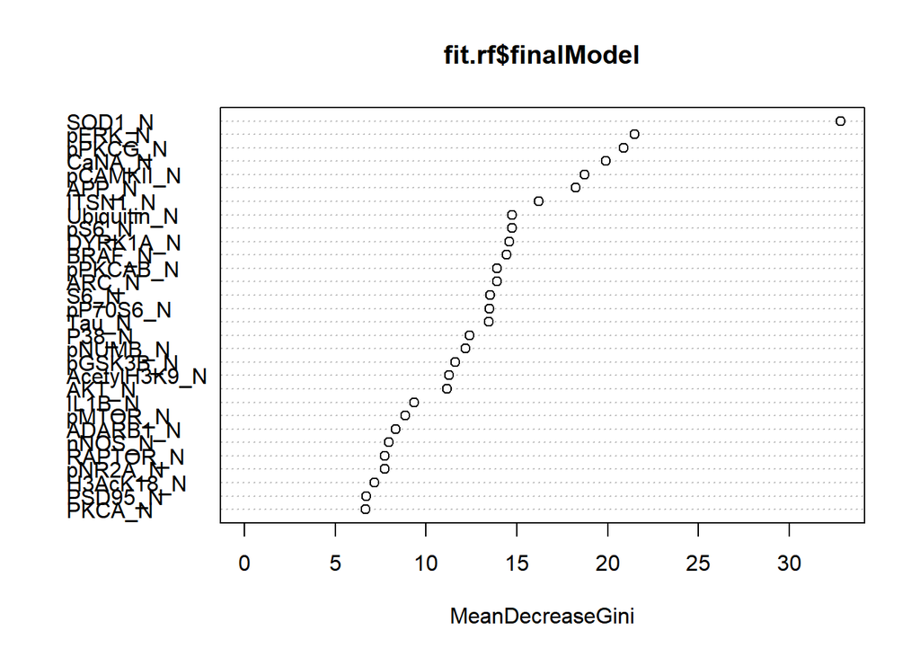

```r
varImpPlot(fit.rf$finalModel)
```

```r
imp<-data.frame(fit.rf$finalModel$importance,var = rownames(fit.rf$finalModel$importance))
imp %>% arrange(desc(MeanDecreaseGini)) %>%
  mutate(csum_gini=cumsum(MeanDecreaseGini)) %>%
  print()
```

```
##    MeanDecreaseGini             var csum_gini
## 1         32.827142          SOD1_N  32.82714
## 2         21.463715          pERK_N  54.29086
## 3         20.877534         pPKCG_N  75.16839
## 4         19.894086          CaNA_N  95.06248
## 5         18.729707       pCAMKII_N 113.79218
## 6         18.243579           APP_N 132.03576
## 7         16.221808         ITSN1_N 148.25757
## 8         14.741008     Ubiquitin_N 162.99858
## 9         14.732366           pS6_N 177.73095
## 10        14.581846        DYRK1A_N 192.31279
## 11        14.419225          BRAF_N 206.73202
## 12        13.922559        pPKCAB_N 220.65458
## 13        13.922343           ARC_N 234.57692
## 14        13.530834            S6_N 248.10775
```

[output cut: 63 more lines]

```r
# First 20 variables covers more than 50% of total gini decrease.
# In this data, every feature has some meaningful information while determining classes.


rf.preds<-predict(fit.rf,test_nuclear,type = "raw")

conf.mat<-confusionMatrix(table(rf.preds,test_nuclear$Y))
print(conf.mat)
```

```
## Confusion Matrix and Statistics
##
##
## rf.preds c1 c2 c3 c4 c5 c6 c7 c8
##       c1 47  0  0  0  0  0  0  0
##       c2  0 38  0  0  0  0  0  0
##       c3  0  0 39  0  0  0  1  0
##       c4  0  0  0 44  0  0  0  0
##       c5  5  1  0  0 53  0  0  0
##       c6  0  0  0  0  0 31  0  0
##       c7  0  0  1  0  0  0 33  0
##       c8  0  0  0  0  0  0  0 31
##
## Overall Statistics
##
##                Accuracy : 0.9753
##                  95% CI : (0.9519, 0.9893)
##     No Information Rate : 0.1636
##     P-Value [Acc > NIR] : < 2.2e-16
##
##                   Kappa : 0.9716
##
##  Mcnemar's Test P-Value : NA
##
## Statistics by Class:
##
##                      Class: c1 Class: c2 Class: c3 Class: c4 Class: c5
## Sensitivity             0.9038    0.9744    0.9750    1.0000    1.0000
## Specificity             1.0000    1.0000    0.9965    1.0000    0.9779
## Pos Pred Value          1.0000    1.0000    0.9750    1.0000    0.8983
## Neg Pred Value          0.9819    0.9965    0.9965    1.0000    1.0000
## Prevalence              0.1605    0.1204    0.1235    0.1358    0.1636
## Detection Rate          0.1451    0.1173    0.1204    0.1358    0.1636
## Detection Prevalence    0.1451    0.1173    0.1235    0.1358    0.1821
## Balanced Accuracy       0.9519    0.9872    0.9857    1.0000    0.9889
##                      Class: c6 Class: c7 Class: c8
## Sensitivity            1.00000    0.9706   1.00000
## Specificity            1.00000    0.9966   1.00000
## Pos Pred Value         1.00000    0.9706   1.00000
## Neg Pred Value         1.00000    0.9966   1.00000
## Prevalence             0.09568    0.1049   0.09568
## Detection Rate         0.09568    0.1019   0.09568
## Detection Prevalence   0.09568    0.1049   0.09568
## Balanced Accuracy      1.00000    0.9836   1.00000
```

```r
rf.perf<-conf.mat$overall["Accuracy"]
print(rf.perf)
```

```
##  Accuracy
## 0.9753086
```

4. Stochastic Gradient Boosting

```r
#We decreased parameter set since gbm takes so much time for multiclass
Grid.Matrix= expand.grid(n.trees=seq(20,300,length.out = 3),
                         interaction.depth=c(5,8,12),
                         shrinkage=c(0.01,0.03,0.05),
                         n.minobsinnode=c(10))
cl <- makeCluster(8)
registerDoSNOW(cl)
set.seed(123)
fit.gbm <- caret::train(x = Traindat ,
                        y = TrainResponse,
                        method = "gbm",
                        trControl = control.param,
                        tuneGrid = Grid.Matrix,
                        metric="Accuracy")
stopCluster(cl)
print(fit.gbm)
```

```
## Stochastic Gradient Boosting
##
## 756 samples
##  77 predictor
##   8 classes: 'c1', 'c2', 'c3', 'c4', 'c5', 'c6', 'c7', 'c8'
##
## No pre-processing
## Resampling: Cross-Validated (10 fold)
## Summary of sample sizes: 681, 679, 678, 681, 682, 681, ...
## Resampling results across tuning parameters:
##
##   shrinkage  interaction.depth  n.trees  logLoss     AUC        prAUC
##   0.01        5                  20      1.50397716  0.9864780  0.8165861
##   0.01        5                 160      0.44729242  0.9974865  0.8763597
##   0.01        5                 300      0.21838230  0.9992108  0.8866516
##   0.01        8                  20      1.48163070  0.9906466  0.8377630
##   0.01        8                 160      0.39064742  0.9985215  0.8826512
##   0.01        8                 300      0.16905096  0.9995691  0.8891212
##   0.01       12                  20      1.48068408  0.9905127  0.8385821
##   0.01       12                 160      0.38486387  0.9985742  0.8824203
##   0.01       12                 300      0.15802769  0.9995975  0.8889977
##   0.03        5                  20      0.94908129  0.9915552  0.8443018
##   0.03        5                 160      0.11712543  0.9996977  0.8900919
##   0.03        5                 300      0.04666633  0.9999793  0.8922325
##   0.03        8                  20      0.91946123  0.9931809  0.8500427
##   0.03        8                 160      0.08936601  0.9996850  0.8899471
##   0.03        8                 300      0.04357137  0.9999378  0.8919220
##   0.03       12                  20      0.91368404  0.9938938  0.8554619
##   0.03       12                 160      0.07713458  0.9998941  0.8915515
##   0.03       12                 300      0.03783667  0.9999585  0.8920859
##   0.05        5                  20      0.67805466  0.9923917  0.8523213
##   0.05        5                 160      0.06036435  0.9998561  0.8914002
##   0.05        5                 300      0.03164539  0.9999793  0.8922325
##   0.05        8                  20      0.63800398  0.9954573  0.8640711
##   0.05        8                 160      0.04584182  0.9998248  0.8909834
##   0.05        8                 300      0.02300974  1.0000000  0.8923791
##   0.05       12                  20      0.62372695  0.9958781  0.8679640
##   0.05       12                 160      0.04363587  0.9999359  0.8919295
##   0.05       12                 300      0.03118393  0.9999579  0.8920686
##   Accuracy   Kappa      Mean_F1    Mean_Sensitivity  Mean_Specificity
```

[output cut: 73 more lines]

```
##   0.1238441            0.9946681
##   0.1127498            0.9418425
##   0.1231797            0.9913579
##   0.1241731            0.9961075
##   0.1150813            0.9533256
##   0.1235043            0.9930840
##   0.1240043            0.9954718
##   0.1167326            0.9617587
##   0.1233441            0.9921968
##   0.1236710            0.9938876
##
## Tuning parameter 'n.minobsinnode' was held constant at a value of 10
## Accuracy was used to select the optimal model using the largest value.
## The final values used for the model were n.trees = 300, interaction.depth =
##  5, shrinkage = 0.05 and n.minobsinnode = 10.
```

```r
varImp(fit.gbm)
```

```
## gbm variable importance
##
##   only 20 most important variables shown (out of 77)
##
##              Overall
## SOD1_N        100.00
## pPKCG_N        86.16
## P38_N          46.93
## CaNA_N         39.59
## Ubiquitin_N    38.19
## ARC_N          34.36
## ITSN1_N        34.36
## pNUMB_N        34.16
## AcetylH3K9_N   33.80
## APP_N          33.32
## BRAF_N         31.58
## pCAMKII_N      29.14
## SYP_N          28.81
## AKT_N          28.77
## pPKCAB_N       27.08
## Tau_N          26.67
## pP70S6_N       23.81
## pERK_N         23.52
## pMTOR_N        21.82
## pGSK3B_N       21.13
```

```r
#SOD1_N is the most important one for both rf and gbm method
gbm.preds=predict(fit.gbm,test_nuclear,type = "raw")

conf.mat<-confusionMatrix(table(gbm.preds,test_nuclear$Y))
print(conf.mat)
```

```
## Confusion Matrix and Statistics
##
##
## gbm.preds c1 c2 c3 c4 c5 c6 c7 c8
##        c1 52  0  0  0  0  0  0  0
##        c2  0 39  0  0  0  0  0  0
##        c3  0  0 40  0  0  0  0  0
##        c4  0  0  0 43  0  0  0  0
##        c5  0  0  0  0 53  0  0  0
##        c6  0  0  0  0  0 31  0  0
##        c7  0  0  0  0  0  0 34  0
##        c8  0  0  0  1  0  0  0 31
##
## Overall Statistics
##
##                Accuracy : 0.9969
##                  95% CI : (0.9829, 0.9999)
##     No Information Rate : 0.1636
##     P-Value [Acc > NIR] : < 2.2e-16
##
##                   Kappa : 0.9965
##
##  Mcnemar's Test P-Value : NA
##
## Statistics by Class:
##
##                      Class: c1 Class: c2 Class: c3 Class: c4 Class: c5
## Sensitivity             1.0000    1.0000    1.0000    0.9773    1.0000
## Specificity             1.0000    1.0000    1.0000    1.0000    1.0000
## Pos Pred Value          1.0000    1.0000    1.0000    1.0000    1.0000
## Neg Pred Value          1.0000    1.0000    1.0000    0.9964    1.0000
## Prevalence              0.1605    0.1204    0.1235    0.1358    0.1636
## Detection Rate          0.1605    0.1204    0.1235    0.1327    0.1636
## Detection Prevalence    0.1605    0.1204    0.1235    0.1327    0.1636
## Balanced Accuracy       1.0000    1.0000    1.0000    0.9886    1.0000
##                      Class: c6 Class: c7 Class: c8
## Sensitivity            1.00000    1.0000   1.00000
## Specificity            1.00000    1.0000   0.99659
## Pos Pred Value         1.00000    1.0000   0.96875
## Neg Pred Value         1.00000    1.0000   1.00000
## Prevalence             0.09568    0.1049   0.09568
## Detection Rate         0.09568    0.1049   0.09568
## Detection Prevalence   0.09568    0.1049   0.09877
## Balanced Accuracy      1.00000    1.0000   0.99829
```

```r
gbm.perf<-conf.mat$overall["Accuracy"]
print(gbm.perf)
```

```
##  Accuracy
## 0.9969136
```

```r
nuclear_perfs<-cbind(c(glmnet.perf,rpart.perf,rf.perf,gbm.perf),
                   c(max(fit.glmnet$results$Accuracy),fit.rpart$y["acc.test.mean"],max(fit.rf$results$Accuracy),max(fit.gbm$results$Accuracy)))


colnames(nuclear_perfs)<-c("Test","CV")
rownames(nuclear_perfs)<-c("glmnet","rpart","rf","gbm")
nuclear_perfs
```

```
##             Test        CV
## glmnet 0.9907407 0.9881377
## rpart  0.8271605 0.8610526
## rf     0.9753086 0.9854867
## gbm    0.9969136 0.9933850
```

Gbm is the best and penalized regression comes second for this question also. cv results are consistent with test results.

Final Conclusion: High lambda in penalized regression and high complexity parameter leads worse performance because of underfit. High n trees and depth in gbm may lead to overfit. We are not suspected of any underfit or overfit in all of the questions except last one. We selected our parameters accordingly and tried to be careful.

Gbm is the best performer for 3 questions. Then, lasso regression comes. 3rd one is random forest. Rpart is the worst one. So, creating 1 decision rule for whole data is not enough.